# DATA 624: PREDICTIVE ANALYTICS HW 9

Gabriel Campos

Last edited April 14, 2024

# Library

```r
library(AppliedPredictiveModeling)
library(caret)
library(corrplot)
library(Cubist)
library(dplyr)
library(earth)
library(forecast)
library(fpp3)
library(gbm)
library(ggplot2)
library(MASS)
library(mice)
library(mlbench)
library(party)
library(randomForest)
library(RANN)
library(rpart)
library(rpart.plot)
library(tidyr)
```

# Description

Do problems 8.1, 8.2, 8.3, and 8.7 in Kuhn and Johnson. Please submit the Rpubs link along with the .rmd file.

# 8.1.

Recreate the simulated data from Exercise 7.2:

```r
set.seed(200)
simulated <- mlbench.friedman1(200, sd = 1)
simulated <- cbind(simulated$x, simulated$y)
simulated <- as.data.frame(simulated)
colnames(simulated)[ncol(simulated)] <- "y"
```

## (a)

Fit a random forest model to all of the predictors, then estimate the variable importance scores:

```r
 model1 <- randomForest(y ~ ., data = simulated,
 importance = TRUE,
 ntree = 1000)
 rfImp1 <- varImp(model1, scale = FALSE)
```

```r
rownames(rfImp1) <- paste0("V", 1:10)
rfImp1_sorted <- rfImp1[order(-rfImp1$Overall), , drop = FALSE] # 'drop = FALSE' ensures the result is still a data frame
print(rfImp1_sorted)
```

|  | Overall |
| --- | --- |
| V1 | 8.732235404 |
| V4 | 7.615118809 |
| V2 | 6.415369387 |
| V5 | 2.023524577 |
| V3 | 0.763591825 |
| V6 | 0.165111172 |
| V7 | -0.005961659 |
| V10 | -0.074944788 |
| V9 | -0.095292651 |
| V8 | -0.166362581 |

Did the random forest model significantly use the uninformative predictors (`V6` – `V10`)?

No. The values of `V6`-`V10` are very low, even most being a negative value indicating a low importance score.

## (b)

Now add an additional predictor that is highly correlated with one of the informative predictors. For example:

```r
simulated$duplicate1 <- simulated$V1 + rnorm(200) * .1
cor(simulated$duplicate1, simulated$V1)
```

```
[1] 0.9460206
```

```r
simulated2<-simulated
simulated2$duplicate1 <- simulated2$V1 + rnorm(200) * .1
cor(simulated2$duplicate1, simulated2$V1)
```

```
[1] 0.9447637
```

Fit another random forest model to these data. Did the importance score for `V1` change? What happens when you add another predictor that is also highly correlated with `V1`?

```r
model2 <- randomForest(y ~ ., data = simulated2, importance = TRUE,
                       ntree = 1000)
rfImp2 <- varImp(model2, scale = FALSE)
```

```r
rownames(rfImp2) <- c(paste0("V", 1:10), "duplicate1")
rfImp2_sorted <- rfImp2[order(-rfImp2$Overall), , drop = FALSE] # 'drop = FALSE' ensures the result is still a data frame
print(rfImp2_sorted)
```

|  | Overall |
| --- | --- |
| V4 | 6.92191640 |
| V1 | 6.51537580 |
| V2 | 6.28207942 |
| duplicate1 | 3.45558605 |
| V5 | 2.05234722 |
| V3 | 0.55644584 |
| V6 | 0.11516713 |
| V10 | -0.03254994 |
| V7 | -0.06291275 |
| V9 | -0.09013857 |

[output cut: 1 more lines]

The highly correlated rearranged the importance score for all predictors. Predictor V1 was demoted from most important to second most important. The highly correlated duplicate lands in fourth place.

## (c)

Use the `cforest` function in the party package to fit a random forest model using conditional inference trees. The party package function `varimp` can calculate predictor importance. The conditional argument of that function toggles between the traditional importance measure and the modified version described in *Strobl et al. (2007)*. Do these importances show the same pattern as the traditional random forest model?

```r
model3 <- cforest(y ~., data = simulated)

order(-varimp(model3, conditional = FALSE)) #default conditional: FALSE
```

```
 [1]  4  2 11  1  5  7  9 10  6  3  8
```

```r
order(-varimp(model3, conditional = TRUE))
```

```
 [1]  4  2 11  1  5  3  9  6  7 10  8
```

which differ in pattern, but do support that v6-v10 have relatively low importance levels.

## (d)

Repeat this process with different tree models, such as boosted trees and Cubist. Does the same pattern occur?

[figure not shown]

### Boosted

|  | var | rel.inf |
| --- | --- | --- |
| V4 | V4 | 29.5838443 |
| V2 | V2 | 23.2710334 |
| V1 | V1 | 18.1143091 |
| V5 | V5 | 10.5014583 |
| duplicate1 | duplicate1 | 9.5810923 |
| V3 | V3 | 8.4854137 |
| V6 | V6 | 0.2478833 |
| V9 | V9 | 0.2149655 |
| V7 | V7 | 0.0000000 |
| V8 | V8 | 0.0000000 |

[output cut: 1 more lines]

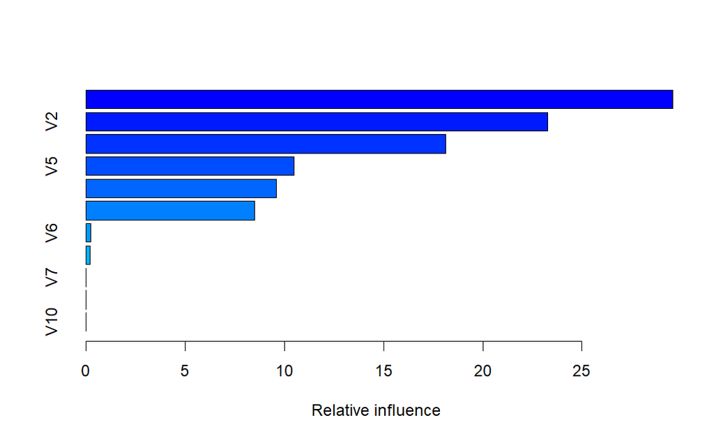

```r
set.seed(624)

model_gbm<- gbm(y ~., data = simulated, distribution = "gaussian")

summary.gbm(model_gbm)
```

### Cubist

```r
simulated_x <- subset(simulated, select = -c(y))

cubist_model <- cubist(x = simulated_x, y = simulated$y, committees = 100)
```

```r
cube_model_v2<-varImp(cubist_model)
rownames(cube_model_v2) <- c(paste0("V", 1:10), "duplicate1")
cubist_sorted <- cube_model_v2[order(-cube_model_v2$Overall), , drop = FALSE]
print(cubist_sorted)
```

|  | Overall |
| --- | --- |
| V3 | 59.5 |
| V2 | 52.5 |
| V5 | 46.0 |
| V1 | 43.5 |
| V4 | 27.5 |
| V7 | 27.0 |
| V8 | 10.0 |
| V6 | 4.0 |
| V9 | 1.0 |
| V10 | 0.0 |

[output cut: 1 more lines]

# 8.2.

Use a simulation to show tree bias with different granularities.

```r
set.seed(624)
#samples for predictors
low <- sample(0:50, 500, replace = T)
medium <- sample(0:500, 500, replace = T)
high <- sample(0:5000, 500, replace = T)

#response
y <- low + medium + high + rnorm(250)

#check variance of predictors
var(low)
```

```
[1] 221.9536
```

```r
var(medium)
```

```
[1] 21752.82
```

```r
var(high)
```

```
[1] 2016913
```

```r
df_sim <- data.frame(low, medium, high, y)

diff_gran_model <- randomForest(y ~., data = df_sim, importance = TRUE, ntree = 1000)

varImp(diff_gran_model, scale=FALSE)
```

|  | Overall |
| --- | --- |
| low | -19996.77 |
| medium | 15806.52 |
| high | 3605673.96 |

The tree model confirms tree bias where highest variance variables (lowest granularity) get ranked with highest importance.

# 8.3.

In stochastic gradient boosting the bagging fraction and learning rate will govern the construction of the trees as they are guided by the gradient. Although the optimal values of these parameters should be obtained through the tuning process, it is helpful to understand how the magnitudes of these parameters affect magnitudes of variable importance. Figure 8.24 provides the variable importance plots for boosting using two extreme values for the bagging fraction (0.1 and 0.9) and the learning rate (0.1 and 0.9) for the solubility data. The left-hand plot has both parameters set to 0.1, and the right-hand plot has both set to 0.9:

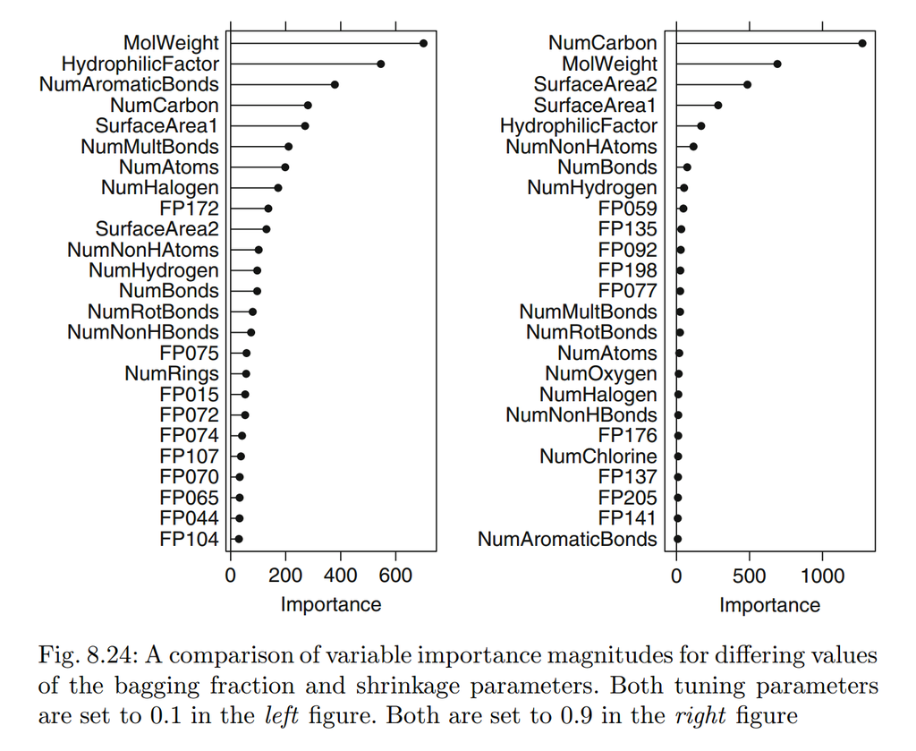

[package gbm](https://www.rdocumentation.org/packages/gbm/versions/2.1.8/topics/gbm)

## (a)

Why does the model on the right focus its importance on just the first few of predictors, whereas the model on the left spreads importance across more predictors?

## (b)

Which model do you think would be more predictive of other samples?

The left model with `shrinkage` = 0.1, `bag.fraction` = 0.1 would be more predictive of other samples between the two. Considering the amount of trees it should have in comparison to the model on the right with `shrinkage` = 0.9, `bag.fraction` = 0.9.

## (c)

How would increasing interaction depth affect the slope of predictor importance for either model in Fig. 8.24?

According to [pub_journals link](https://www.fs.fed.us/rm/pubs_journals/2015/rmrs_2015_freeman_e001.pdf) Sec 4.2, pg. 15

- The relationship between shrinkage (learning rate) and interaction depth (tree complexity) in decision tree models, specifically in boosting.
- Shrinkage is inversely related to interaction depth, meaning as tree complexity increases, the learning rate should decrease to prevent overfitting and maintain model stability.
- This slower learning process necessitates using more trees.
- Larger datasets better support more complex trees, as they can handle the detailed structures these trees create without overfitting quickly. *Interaction depth/tree size or tree complexity, affects the maximum size for each tree.
- As mentioned there is a inverse relationship with shrinkage to interaction depth.
- The left (`shrinkage` = 0.1, `bag.fraction` = 0.1) is likely to benefit from increasing interaction depth.
- But the right might not since the shrinkage parameter is already so high.

# 8.7.

Refer to Exercises 6.3 and 7.5 which describe a chemical manufacturing process. Use the same data imputation, data splitting, and pre-processing steps as before and train several tree-based models:

```r
#load data
data(ChemicalManufacturingProcess)

set.seed(624)
imputed_data <- preProcess(ChemicalManufacturingProcess, method = c("knnImpute","nzv", "corr"))
df_full <- predict(imputed_data, ChemicalManufacturingProcess)

chem_index <- createDataPartition(df_full$Yield , p=.8, list=F)

chem_train <-  df_full[chem_index,]
chem_test <- df_full[-chem_index,]

train_pred <- chem_train[-c(1)]
test_pred<-  chem_test[-c(1)]
```

## (a)

Which tree-based regression model gives the optimal resampling and test set performance?

### Boosted Trees

```r
set.seed(624)
gbm_model <- gbm.fit(train_pred, chem_train$Yield, distribution = "gaussian")
gbm_model
```

```
A gradient boosted model with gaussian loss function.
100 iterations were performed.
There were 46 predictors of which 7 had non-zero influence.
```

```r
gbm_pred <- predict(gbm_model, newdata = test_pred)
postResample(pred = gbm_pred, obs = chem_test$Yield)
```

```
     RMSE  Rsquared       MAE
1.1097582 0.5627084 0.8634997
```

### Cubist

```r
set.seed(624)
cube_model <- cubist(train_pred, chem_train$Yield)
cube_model
```

```
Call:
cubist.default(x = train_pred, y = chem_train$Yield)

Number of samples: 144
Number of predictors: 46

Number of committees: 1
Number of rules: 2
```

```r
cube_pred <- predict(cube_model, newdata = test_pred)
postResample(pred = cube_pred, obs = chem_test$Yield)
```

```
     RMSE  Rsquared       MAE
0.6724398 0.6903309 0.5159054
```

### Random Forest

```r
set.seed(624)
#fit the model
rf_model <- randomForest(train_pred, chem_train$Yield, importance = TRUE, ntrees = 1000)
rf_model
```

```
Call:
 randomForest(x = train_pred, y = chem_train$Yield, importance = TRUE,      ntrees = 1000)
               Type of random forest: regression
                     Number of trees: 500
No. of variables tried at each split: 15

          Mean of squared residuals: 0.3711346
                    % Var explained: 59.85
```

```r
rf_pred <- predict(rf_model, newdata = test_pred)
postResample(pred = rf_pred, obs = chem_test$Yield)
```

```
     RMSE  Rsquared       MAE
0.6715320 0.7323224 0.4828902
```

Random Forest has the optimal metrics because of its RMSE of 0.6715320 (lowest) and Rsquared of 0.7323224

## (b)

```r
rf_model_v2<-varImp(rf_model)
```

```r
#rownames(rf_model_v2) <- c(paste0("V", 1:10), "duplicate1")
rf_model_sorted <- rf_model_v2[order(-rf_model_v2$Overall), , drop = FALSE] # 'drop = FALSE' ensures the result is still a data frame
head(rf_model_sorted,10)
```

|  | Overall |
| --- | --- |
| ManufacturingProcess32 | 21.996175 |
| BiologicalMaterial06 | 12.943335 |
| BiologicalMaterial03 | 11.767253 |
| ManufacturingProcess36 | 9.989997 |
| BiologicalMaterial11 | 9.396847 |
| ManufacturingProcess13 | 9.195379 |
| BiologicalMaterial08 | 8.546350 |
| ManufacturingProcess09 | 7.580592 |
| BiologicalMaterial09 | 7.019902 |
| ManufacturingProcess28 | 6.992895 |

### i

Which predictors are most important in the optimal tree-based regression model? Do either the biological or process variables dominate the list?

`ManufacturingProcess32` is the most important.Neither of the predictors dominating the list with 5 `ManufacturingProcess` and 5 `BiologicalProcess` in the top ten.

### ii

How do the top 10 important predictors compare to the top 10 predictors from the optimal linear and nonlinear models?

This combination is basically consistent with the importance variables of the non-linear model, not so much the linear model.

## (c)

Plot the optimal single tree with the distribution of yield in the terminal nodes. Does this view of the data provide additional knowledge about the biological or process predictors and their relationship with yield?

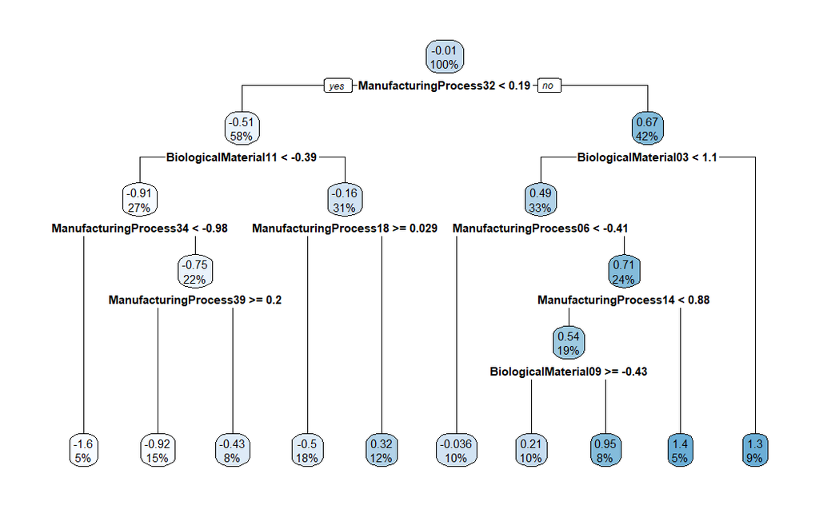

```r
rpart_tree <- rpart(Yield ~., data = chem_train)
rpart.plot(rpart_tree)
```